# Eksplorasi Pola Data

Arsa

2026-03-11

# Data Transaksi dan Indeks Saham di Bursa Efek Jakarta

## Data time series Nilai Saham

Data yang digunakan merupakan data nilai transaksi dan indeks saham di Bursa Efek Indonesia sebanyak 108 observasi dari awal tahun 2017 sampai akhir tahun 2025 yang diperoleh dari publikasi resmi Badan Pusat Statistik (BPS). Data ini disajikan dalam bentuk runtun waktu bulanan dan memuat informasi mengenai nilai transaksi saham (dalam milyar rupiah) serta pergerakan indeks saham pada setiap periode. Data menunjukkan perubahan dari bulan ke bulan dengan fluktuasi yang cukup besar, mencerminkan dinamika aktivitas perdagangan saham di pasar modal Indonesia selama periode pengamatan.

```
##     Tahun     Bulan Nilai.Saham..Milyar.Rupiah.
## 1    2017   Januari                      119291
## 2    2017  Februari                      143350
## 3    2017     Maret                      171063
## 4    2017     April                      173441
## 5    2017       Mei                      164356
## 6    2017      Juni                      109812
## 7    2017      Juli                      131863
## 8    2017   Agustus                      138775
## 9    2017 September                      126037
## 10   2017   Oktober                      168929
## 11   2017  November                      187096
## 12   2017  Desember                      175579
## 13   2018   Januari                      198902
## 14   2018  Februari                      172056
```

[output cut: 94 more lines]

```
## 'data.frame':    108 obs. of  3 variables:
##  $ Tahun                      : num  2017 2017 2017 2017 2017 ...
##  $ Bulan                      : chr  "Januari" "Februari" "Maret" "April" ...
##  $ Nilai.Saham..Milyar.Rupiah.: num  119291 143350 171063 173441 164356 ...
```

## Grafik time series Nilai Saham

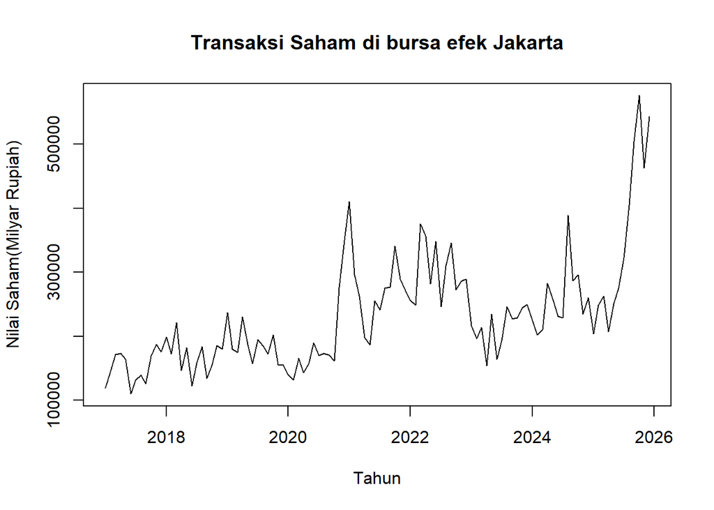

## Grafik ACF Nilai Saham

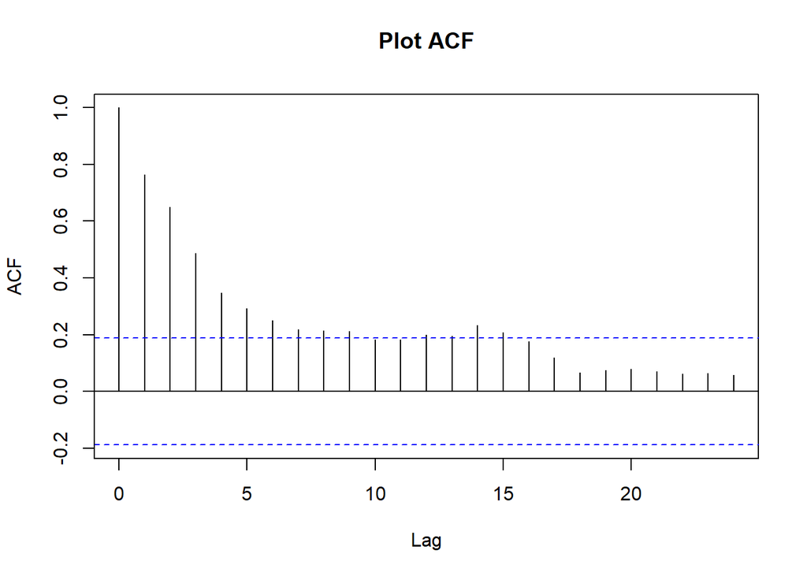

## Kesimpulan Nilai Saham

Berdasarkan plot deret waktu (time series) nilai saham dari Januari 2017 hingga Desember 2025, terlihat bahwa data menunjukkan kecenderungan meningkat dari waktu ke waktu meskipun disertai fluktuasi pada beberapa periode. Hal ini menunjukkan adanya pola tren meningkat (upward trend) pada data. Selain itu, dari grafik deret waktu tidak terlihat adanya pola yang berulang secara teratur setiap periode tertentu, sehingga pola musiman tidak tampak secara jelas.

Hasil tersebut juga didukung oleh plot Autocorrelation Function (ACF) dengan lag maksimum 24 yang menunjukkan bahwa nilai autokorelasi pada beberapa lag awal bernilai positif dan signifikan, kemudian menurun secara bertahap seiring bertambahnya lag. Pola autokorelasi yang menurun secara gradual ini menunjukkan bahwa data memiliki ketergantungan antar waktu, di mana nilai pada suatu periode dipengaruhi oleh nilai pada periode sebelumnya.

Dengan demikian, dapat disimpulkan bahwa data deret waktu nilai saham memiliki pola tren dengan ketergantungan temporal yang cukup kuat pada beberapa periode awal, namun tidak menunjukkan pola musiman yang jelas.

# Data Penumpang Angkutan Kereta Api Nasional

## Data time series Penumpang Kereta Api

Data yang digunakan merupakan data jumlah penumpang angkutan kereta api nasional bulanan yang diperoleh dari Badan Pusat Statistik (BPS). Data disajikan berdasarkan periode bulan dan tahun, dengan variabel utama berupa total jumlah penumpang kereta api di Indonesia pada setiap bulan. Data berbentuk runtun waktu dengan frekuensi bulanan dan memuat 96 observasi. Nilai data menunjukkan perubahan jumlah penumpang dari bulan ke bulan selama periode tahun 2017 sampai akhir tahun 2024.

```
##    Tahun     Bulan Jumlah.Penumpang..Orang.
## 1   2017   Januari                    30949
## 2   2017  Februari                    27342
## 3   2017     Maret                    32170
## 4   2017     April                    31502
## 5   2017       Mei                    33745
## 6   2017      Juni                    30723
## 7   2017      Juli                    34310
## 8   2017   Agustus                    33791
## 9   2017 September                    32498
## 10  2017   Oktober                    35070
## 11  2017  November                    34361
## 12  2017  Desember                    36807
## 13  2018   Januari                    34741
## 14  2018  Februari                    31278
```

[output cut: 82 more lines]

```
## 'data.frame':    96 obs. of  3 variables:
##  $ Tahun                   : num  2017 2017 2017 2017 2017 ...
##  $ Bulan                   : chr  "Januari" "Februari" "Maret" "April" ...
##  $ Jumlah.Penumpang..Orang.: num  30949 27342 32170 31502 33745 ...
```

## Grafik time series Penumpang Kereta Api

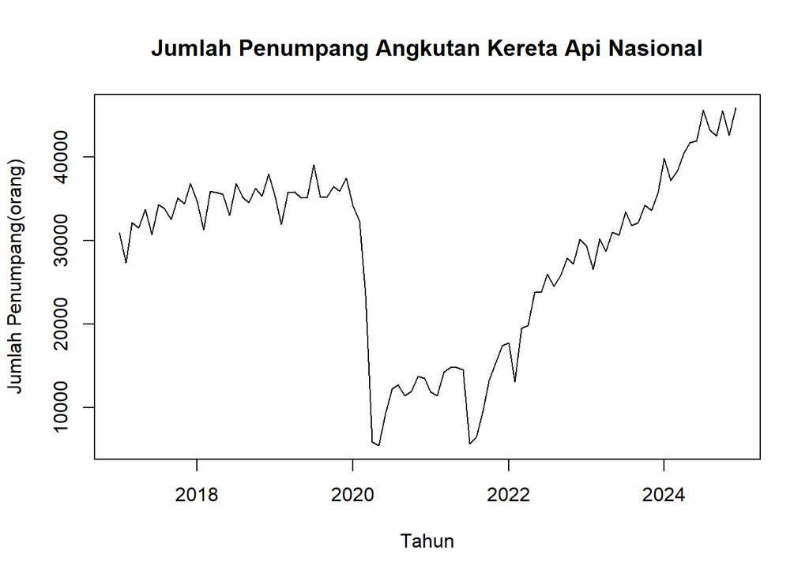

## Grafik ACF Penumpang Kereta Api

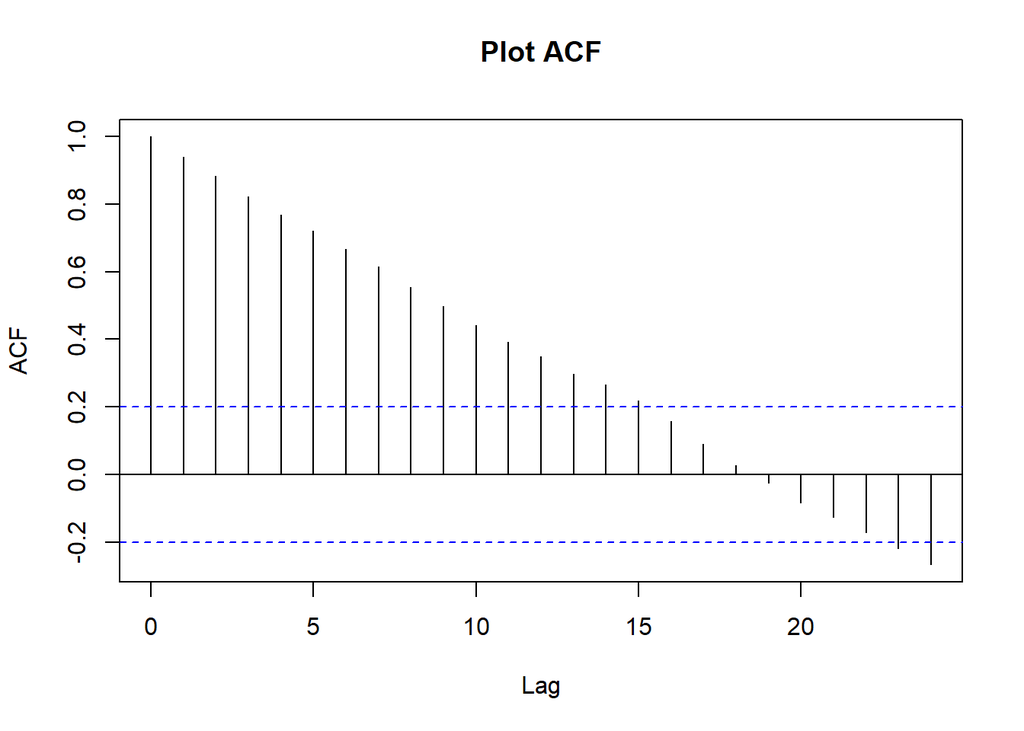

## Kesimpulan Penumpang Kereta Api

Berdasarkan plot time series jumlah penumpang kereta api nasional, terlihat bahwa data menunjukkan tren yang cenderung meningkat dalam jangka panjang, meskipun terdapat fluktuasi dari bulan ke bulan. Selain itu, terlihat adanya penurunan yang sangat tajam pada sekitar tahun 2020, kemudian jumlah penumpang kembali meningkat secara bertahap pada periode setelahnya.

Hasil tersebut juga didukung oleh plot Autocorrelation Function (ACF) yang menunjukkan bahwa nilai autokorelasi pada beberapa lag awal bernilai positif dan cukup besar, kemudian menurun secara bertahap seiring bertambahnya lag. Hal ini menunjukkan bahwa data memiliki ketergantungan antar waktu, di mana nilai pada suatu periode dipengaruhi oleh nilai pada periode sebelumnya.

Dengan demikian, dapat disimpulkan bahwa data jumlah penumpang kereta api memiliki pola tren dengan fluktuasi bulanan serta hubungan antar periode yang cukup kuat, sehingga data tidak bersifat acak dan masih memiliki pola yang dapat dianalisis lebih lanjut.

# Data Minyak mentah WTI berjangka

## Data time series harga penutup minyak mentah WTI

Data yang digunakan merupakan data harga penutupan (closing price) minyak mentah WTI berjangka dalam satuan dolar Amerika Serikat (USD) untuk periode 2021 hingga awal 2026. Data ini berbentuk runtun waktu berukuran 60 dengan frekuensi bulanan dan menunjukkan pergerakan harga dari satu periode ke periode berikutnya. Secara umum, harga mengalami kenaikan tajam hingga pertengahan 2022, kemudian menurun dan bergerak fluktuatif pada periode berikutnya, dengan beberapa kali kenaikan dan penurunan yang cukup signifikan. Perubahan harga tersebut mencerminkan dinamika pasar minyak dunia yang dipengaruhi oleh kondisi ekonomi global, kebijakan produksi, serta faktor geopolitik.

```
##       Tanggal Harga.penutup..USD.
## 1  2021-04-01               63.58
## 2  2021-05-01               66.32
## 3  2021-06-01               73.47
## 4  2021-07-01               73.95
## 5  2021-08-01               68.50
## 6  2021-09-01               75.03
## 7  2021-10-01               83.57
## 8  2021-11-01               66.18
## 9  2021-12-01               75.21
## 10 2022-01-01               88.15
## 11 2022-02-01               95.72
## 12 2022-03-01              100.28
## 13 2022-04-01              104.69
## 14 2022-05-01              114.67
```

[output cut: 46 more lines]

```
## 'data.frame':    60 obs. of  2 variables:
##  $ Tanggal            : POSIXct, format: "2021-04-01" "2021-05-01" ...
##  $ Harga.penutup..USD.: num  63.6 66.3 73.5 74 68.5 ...
```

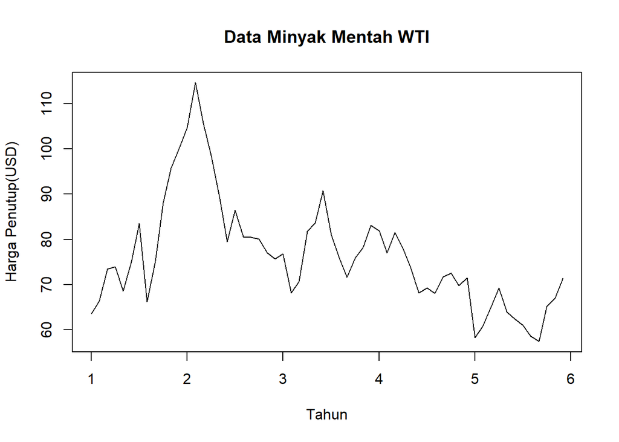

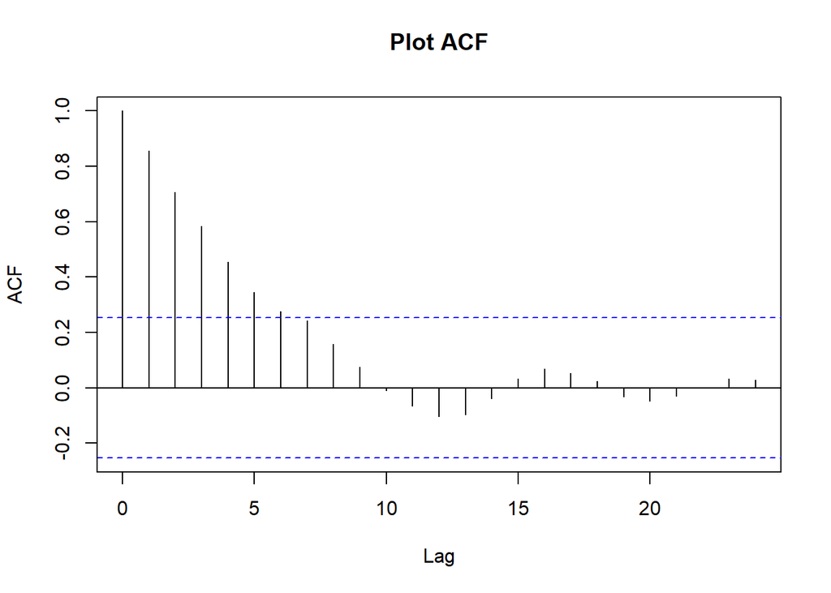

## Kesimpulan

Berdasarkan plot time series harga minyak mentah WTI, terlihat bahwa data mengalami fluktuasi yang cukup besar dari waktu ke waktu. Pada awal periode terlihat adanya kenaikan harga yang cukup tajam hingga mencapai puncak, kemudian diikuti oleh penurunan dan pergerakan naik turun pada periode selanjutnya. Hal ini menunjukkan bahwa data tidak memiliki tren jangka panjang yang konsisten, melainkan lebih didominasi oleh pola fluktuasi harga dari waktu ke waktu.

Hasil tersebut juga didukung oleh plot Autocorrelation Function (ACF) yang menunjukkan bahwa nilai autokorelasi pada beberapa lag awal bernilai positif dan cukup besar, kemudian menurun secara bertahap seiring bertambahnya lag hingga mendekati nol. Hal ini menunjukkan bahwa nilai harga minyak pada suatu periode masih berkaitan dengan nilai pada periode sebelumnya, namun pengaruh tersebut semakin melemah pada lag yang lebih besar.

Dengan demikian, dapat disimpulkan bahwa data harga minyak mentah WTI menunjukkan pola fluktuatif atau siklis lemah dengan autokorelasi yang cukup kuat pada beberapa lag awal, namun tidak menunjukkan pola tren maupun pola musiman yang jelas.